# Project2

Palash Pawar

2024-11-14

# 2018-2019 English Premier League Statistics

### Introduction

This dataset contains individual player statistics from the 2018-2019 English Premier League season, offering insights into one of the world’s top soccer leagues. The source of the dataset was [FootyStats](https://footystats.org/download-stats-csv). By analyzing metrics such as goals, assists, minutes played, and player positions, this project investigates the performance patterns of players across different roles. The goal is to identify statistical relationships that highlight the contributions of various positions and characteristics to overall team success.

[figure not shown]

https://www.skysports.com/football/news/11661/11463347/premier-league-season-preview-club-by-club-guide-to-2018-19

### Data Preparation

```r
library(readr)

soccer <- read_csv("england-premier-league-players-2018-to-2019-stats.csv")
```

I downloaded the dataset as a CSV file containing player statistics for the 2018-2019 Premier League season and imported it into R using the `read_csv()` function. I didn’t run into any challenges when uploading the dataset.

### Variable Descriptions

Variable Descriptions

| Variable | Type | Description |
| --- | --- | --- |
| full_name | Character | Player name |
| goals_overall | Numeric | Number of goals scored by the player |
| assists_overal | Numeric | Number of assists made by the player |
| minutes_played_overall | Numeric | Total minutes played in the season |
| position | Character | Position of the player on the field |

### Univariate Analysis

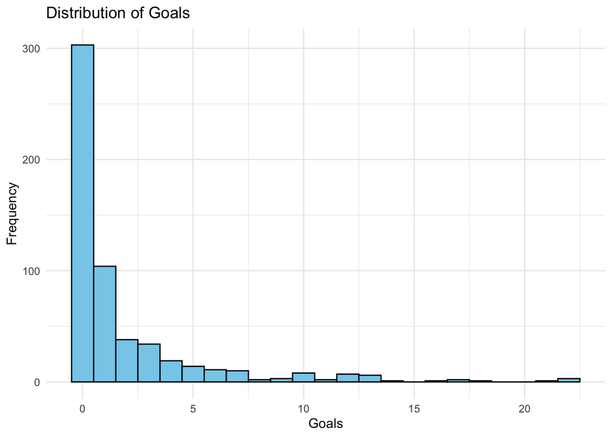

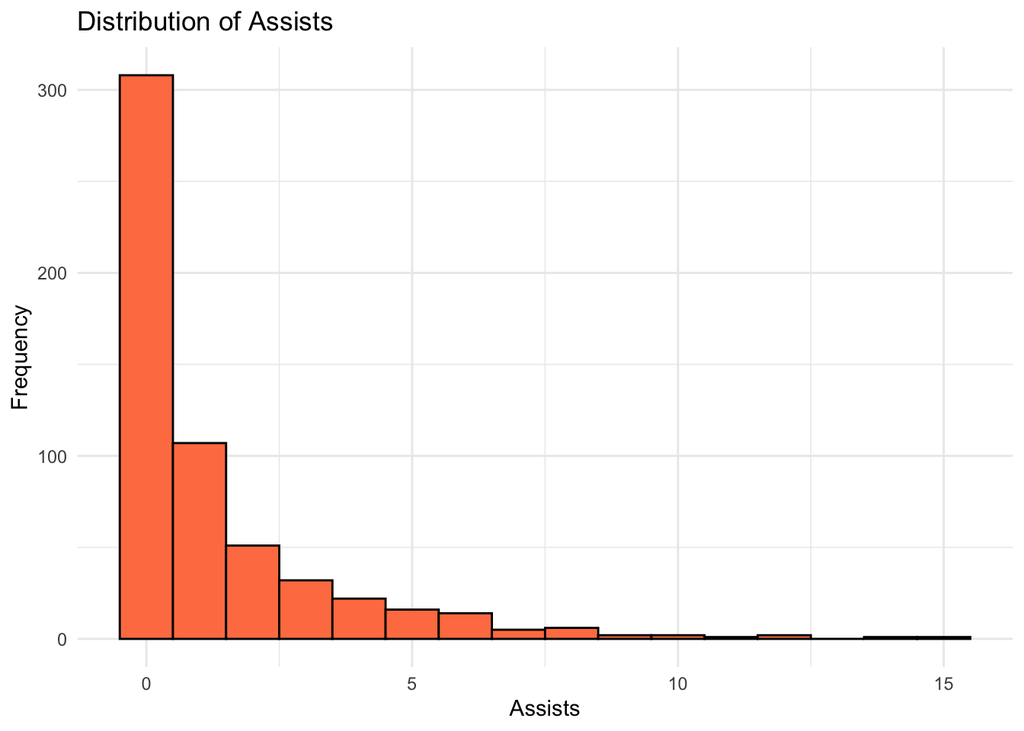

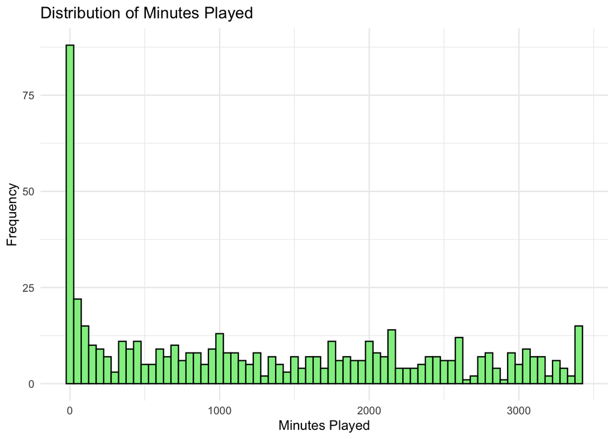

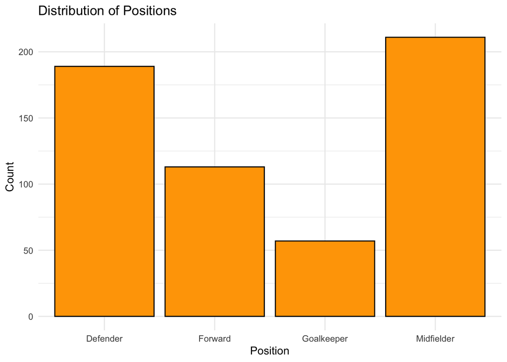

### Bivariate Analysis

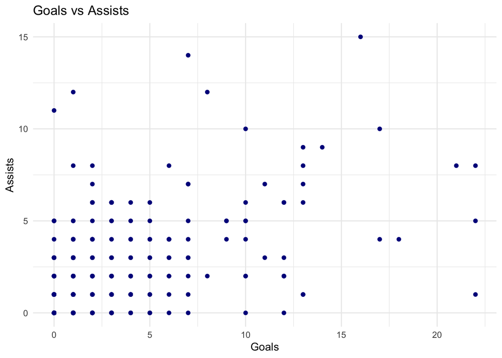

```r
# Goals vs. Assists
ggplot(soccer, aes(x = goals_overall, y = assists_overall)) +
  geom_point(color = "darkblue") +
  labs(title = "Goals vs Assists", x = "Goals", y = "Assists") +
  theme_minimal()
```

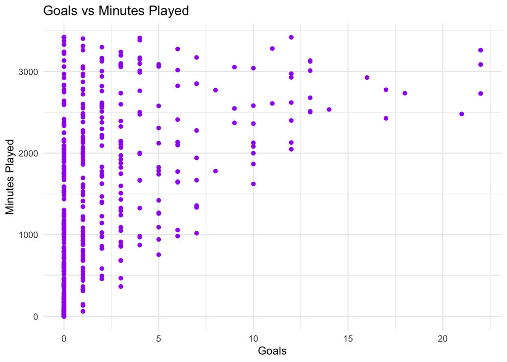

```r
# Goals vs. Minutes Played
ggplot(soccer, aes(x = goals_overall, y = minutes_played_overall)) +
  geom_point(color = "purple") +
  labs(title = "Goals vs Minutes Played", x = "Goals", y = "Minutes Played") +
  theme_minimal()
```

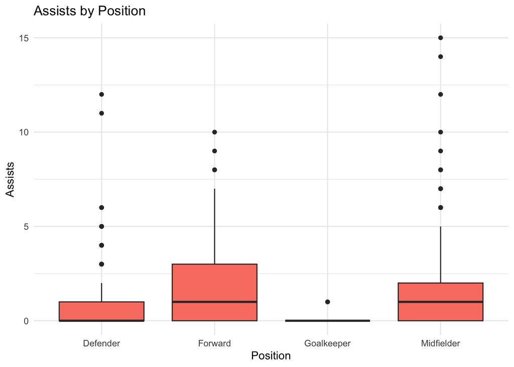

```r
# Assists vs. Position
ggplot(soccer, aes(x = position, y = assists_overall)) +
  geom_boxplot(fill = "salmon") +
  labs(title = "Assists by Position", x = "Position", y = "Assists") +
  theme_minimal()
```

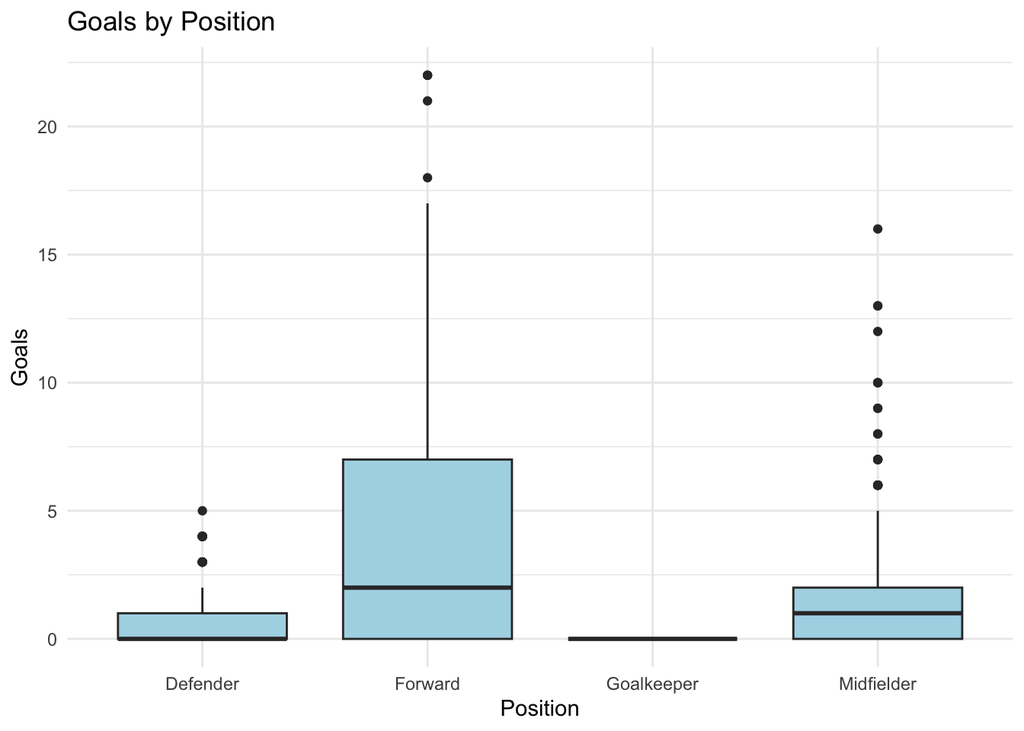

```r
# Goals vs. Position
ggplot(soccer, aes(x = position, y = goals_overall)) +
  geom_boxplot(fill = "lightblue") +
  labs(title = "Goals by Position", x = "Position", y = "Goals") +
  theme_minimal()
```

```r
soccer <- soccer |>
  mutate(goals_per_minute = goals_overall / minutes_played_overall)

soccer <- soccer |>
  mutate(assists_per_minute = assists_overall / minutes_played_overall)
```